# Flight network dynamics in response to COVID 19

2002684

# **1. Introduction**

The COVID-19 pandemic was detrimental to the airline industry and for international passengers (Varghese 2020). Not only were most passenger flights grounded, but changing international and regional dynamics could be observed with a growing fear and hostility to mobility, and shifts to localisation and economic protectionism within blocks like the European Union (EU) and the Association of South-East Asian Nations (ASEAN) (Rodrigue 2020; Wang et al 2020). These trends are potentially visible in flight networks, with an analysis of flights both pre- and post-pandemic. This is important for geography, as it has implications for global mobility and accessibility, trade relations, economic policy, and globalisation (Cresswell 2021; Rodrigue 2020). Moreover, there is a growing acknowledgement that data analytics of such networks is essential for improving air traffic resiliency and planning (Mueller 2021; Varghese 2020).

To explore this, this report presents a review of the current literature, followed by 2 hypotheses and research questions to explore gaps in research. This is followed by a discussion of the results of statistical and network analysis of flight networks, its limitations, and a conclusion to summarise how COVID has impacted flight networks.

# **2. Literature Review**

### Global connectivity

Connectivity is substantially facilitated by flight networks, often fundamental to economic growth (Zhang et al 2022). Many airport hubs exist, which act as crucial nodes enhancing global connectivity between regions that would otherwise be hard to access (ibid).

Connectivity was hindered by the pandemic, due to fears of disease transmission and border closures (see Mueller 2021). This was detrimental, especially for hubs which would normally facilitate connecting flights; domestic flights instead, while already dominant, became far more prominent in the global flight network (see Bouwer et al 2020).

### Hub-and-Spoke patterns

Hub-and-Spoke models are widely used in data analytics and transport networks. The model describes a process which is based around a central points (hub), such as a major airport, and several paths which emerge from that hub (Derr 2023).

The airline industry is modeled around this, but has presented some flaws in its resilience to crisis (Bouwer et al 2020); the demand for connecting flights declined due to preferences for non-stop flying (ibid). Despite this, the authors believed that the model will likely remain dominant for some years to come.

### Uneven recovery

The recovery of airlines was not spatially consistent once travel restrictions were alleviated, with many continents not seeing a full recovery until 2023 (Pele 2023; Gelhausen et al 2021). This is partly due to spatially varied infection rates, differential economic resilience and capacities to redirect flights or adapt planes themselves, and the pace in which travel restrictions were removed (see Pele 2023).

Airport capacities post-pandemic have also been raised as issues in light of COVID, which may impact the demand for flights to and from major airline hubs, or place strain on regions with less mature flight networks (Gelhausen et al 2021).

### Protectionism

The pandemic has accelerated economic shifts towards protectionism, reshoring, and a hostility to mobility (Kang et al 2020; Cresswell 2020).

However, protectionism may not enhance national resiliency, especially if policies are rashly adopted, which could have unforeseen consequences for future risks (Kang et al 2020). This is conceptualised in Agnew’s (1994) ‘territorial trap’, which is highly critical of viewing regions or nations as distinct units which are independent of regional and international forces and trends (Wang et al 2020).

### Airport network methods

Many papers have explored and analysed airport and flight dynamics but, according to Azzam (2017), network analysis of airport evolution is under-explored.

Azzam (2017) used hierarchical clustering to establish several groupings of airports based on their characteristics. Taxonomic groupings are helpful because, as Azzam (2017) discovered, most airports evolve in similar ways, which is important to understand for planning infrastructure and related economic policy, supply chain dynamics, employment, as well as understanding where the network might become vulnerable in the future (ibid).

Parameters adopted by Azzam (2017) include accessibility and centrality measures to indicate network integration, and passenger seat numbers. Such information led to the conclusion that 12 major airport clusters existed within the network, all having distinct characteristics related to their utilisiation within the network, whether they act as international hubs or appear on the periphery of networks.

Other regional network explorations have been conducted by Li and Cai’s (2004) analysis of China, and Hossain et al’s focus on Australian flight networks (2013). Both papers identified shared features within these regional analyses, including small-world characteristics, demonstrating how airports organise around a hub-and-spoke model. Such a dynamic is important considering global crises like COVID (Hossain et al 2013), where if nodes of high degrees are taken out of the network, the knock on effects to the wider network could be substantial.

# **3. Research Questions and Hypotheses**

H1. The pandemic revealed an even greater importance of regional networks as opposed to international networks.

H2. Network accessibility decreased during COVID.

RQ1. Did the hub-and-spoke model hinder network resilience to COVID?

# **4. Data**

This project uses three snapshots from the OpenSky Network aircraft database raw data during the COVID period. Due to the scope of the range of dates provided in the chosen database, snapshots were taken from January 2019 to try and see the most normal flight network arrangements, April 2020, immediately after many lockdown measures were introduced globally, and December 2020, which coincides with many restrictions starting to be lifted. Airport codes were derived from a publicly available data frame from Open Flights (no date) in order to match the airport IACO codes. Moreover, to enable more regional analysis, continent names were obtained from Our World in Data (no date).

# **5. Methods**

To set up the data frames, frequency columns were added by counting the occurrence of origin and destination pairs. Next, the data was filtered to only contain flight pairs with a frequency above 5, since the frequency distribution was significantly positively skewed, as well as the removal of NA values which would interrupt analysis. Several calculations, maps, and plots were used to answer each of the hypotheses and research question, depending on the nature of the question. For example, network parameters were then calculated for each time period, and for regional and international networks to enable comparison in resilience. Maps and network plots were also created to display flight paths changes before and after COVID, as well as displaying the changing structure of airport communities in response to the pandemic.

# **6. Results**

## **6.1. H1**

## Regional flight summary

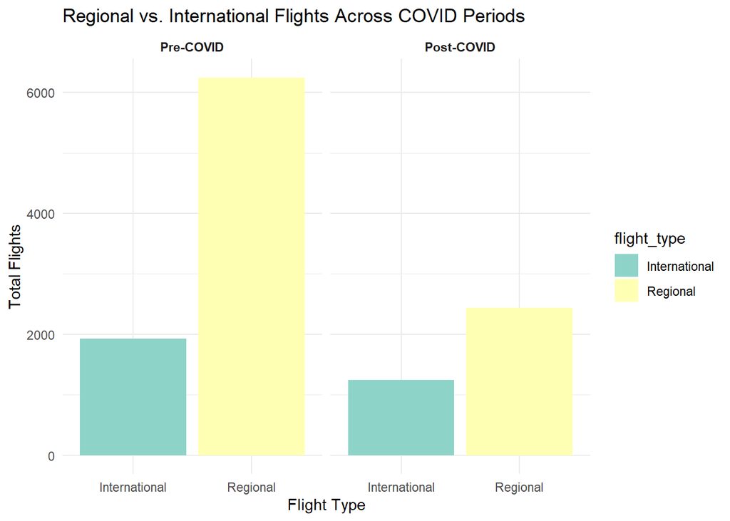

Relatively, the importance of regional flights has clearly always been more important given their much higher frequency in these flight networks. This preference for regional flights was most obvious pre-COVID, which had approximately three times as many flights as the international flights. This importance relatively is much less substantial during COVID and post-COVID. However, there is no way of identifying if any of these are connecting flights, so it only represents non-stop flights; some of the share of regional flights may indeed overall have been for international connections.

# Regional analysis

| Metric | Pre_COVID | Post_COVID |
| --- | --- | --- |
| Regional Density | 1.0133070 | 0.3863924 |
| International Density | 0.4227392 | 0.2730465 |
| Regional Average Degree | 158.0759000 | 61.0500000 |
| International Average Degree | 56.6470600 | 36.5882400 |

The slower recovery of network density is probably due to borders closures and travel restrictions, making many flight routes not commercially viable, and only routes facilitating trade would have been prioritised.

The average degree for the regional flights declined rapidly, but this might be due to the contribution of domestic flights, which is not identified in the network data sets. Regional flights were not as affected by COVID restrictions, but the results suggest otherwise. This may be due to the regions being taken as whole continents, which can be quite expansive in themselves; some international routes in this data may technically be shorter.

The decline in average degree both regionally and internationally suggests recovery to pre-COVID levels may be slow, but the relative effect on international networks seems less.

| Network | Period | Diameter |
| --- | --- | --- |
| Regional | Pre-COVID | 4 |
| Regional | Post-COVID | 4 |
| International | Pre-COVID | 4 |
| International | Post-COVID | 5 |

Only the regional diameter recovers post-COVID, suggesting it is more resilient to reaching the wider network post-crisis.

# Flight paths

```r
merged_frequency <- merge(aggregated_pre.cov, aggregated_post.cov,
                   by = c("origin.y", "destination.y"),
                   all = TRUE)

merged_frequency$Pre_Frequency[is.na(merged_frequency$Pre_Frequency)] <- 0

merged_frequency$Post_Frequency[is.na(merged_frequency$Post_Frequency)] <- 0


merged_frequency$Frequency_change <- ifelse(
  merged_frequency$Pre_Frequency == 0,
  ifelse(merged_frequency$Post_Frequency == 0, 0, Inf),
  ((merged_frequency$Post_Frequency - merged_frequency$Pre_Frequency) / merged_frequency$Pre_Frequency) * 100
)
```

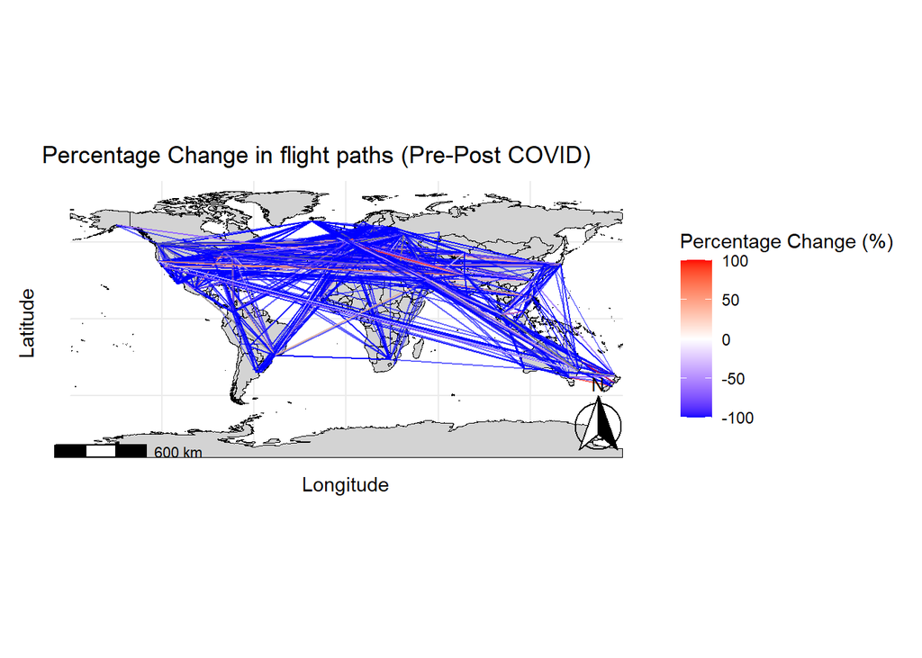

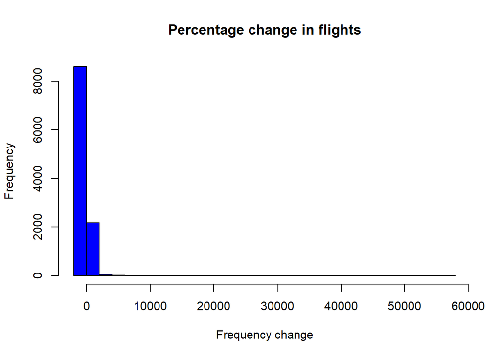

# Community Detection

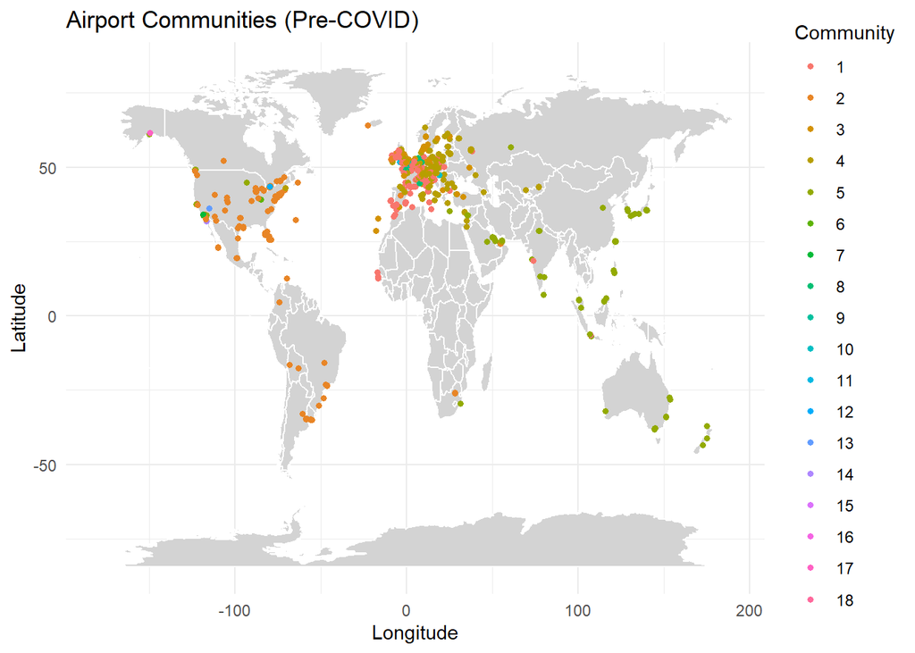

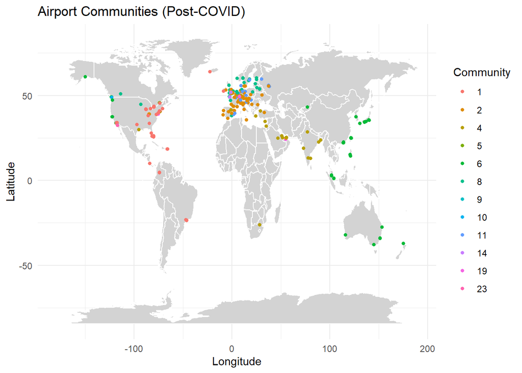

Before the pandemic, the airport communities seem to be incredibly dispersed, with some containing at least 4 continents in their remit. Flight network before the pandemic were highly interconnected, serving a much higher diversity of routes and frequencies to meet demand not only for trade, but also leisure and business travel.

Post-COVID, the alignments with continents very clear. Airport communities are more localised, which indicates international routes had not restored to their previous demand, or re-introduced at all. This is useful information for policy makers because, given the more localised effects on communities, this could enhance understandings of regional interconnectivity and economic recovery, highlighting weak spots in the network which prevent it from reaching its original, interconnected potential.

# Frequency-pairs

## Pre-COVID

| Origin Country | Destination Country | total_flights |
| --- | --- | --- |
| United Kingdom | Germany | 5732 |
| Germany | United Kingdom | 5323 |
| Mexico | United States of America | 5089 |
| United States of America | Canada | 3876 |
| Canada | United States of America | 3703 |
| United States of America | Mexico | 3440 |
| Spain | United Kingdom | 3377 |
| Netherlands | United Kingdom | 3277 |
| Ireland | United Kingdom | 3200 |
| United Kingdom | Ireland | 3042 |

Most of the country pairs with the highest frequency of connecting flights prior to COVID are in the Global North, with the exception of Mexico. The country pair is from the United Kingdom (UK) to Germany, which is to be expected since they are home to some of the largest airport hubs, including major airports like Heathrow, Gatwick, and Manchester, and Frankfurt, Munich, and Berlin airports in Germany. Within these pairs, the UK appears 6 times, followed by the USA 4 times. As shown by the map of airports globally, the geographical clustering around these regions and sheer volume of airports and flights makes this pattern unsurprising. Another observation is that the range of frequencies within this top 10 set seem relatively well distributed, which is not the case for later periods.

## Post-COVID

| Origin Country | Destination Country | total_flights |
| --- | --- | --- |
| United States of America | United Kingdom | 3865 |
| United States of America | Canada | 2761 |
| South Korea | United States of America | 1651 |
| Morocco | France | 1546 |
| United States of America | Puerto Rico | 1534 |
| Puerto Rico | United States of America | 1329 |
| Canada | United States of America | 1296 |
| Mexico | United States of America | 1214 |
| Bermuda | Canada | 1195 |
| United States of America | South Korea | 1167 |

The USA here remains dominant in these patterns, occurring 8 times. Moreover, there are now more Global South nations within these pairings, including Mexico and Morocco. Morocco and Bermuda are surprising to emerge within this, given that they do not host any major international airport hubs. Morocco’s Mohammed V International Airport is the country’s largest, and also one of the largest in Africa, but even in 2024 the passenger numbers are yet to recover to pre-pandemic levels (Karuwa 2024).

# Summary

The changing dynamics within the flight network are evident, especially when regional and international networks are compared. While many scholars believe that the regional level of the flight network has emerged as more important, this isn’t always reflected in the data. However, this may be because the Post-Covid period would still encompass a time when many flight restrictions were in place. That being said, it appears that the relative importance of regional flights still remains high.

It is not possible to say with certainty that regional connections became even more important during and after COVID as suggested in the literature; one would have too look at a period even more recent to understand this.

## **6.2. H2**

```r
pre_cov.point1 <- st_as_sf(x = pre_cov,
                        coords = c("longitude_1", "latitude_1"),
                        crs = "+proj=longlat +datum=WGS84 +ellps=WGS84 +towgs84=0,0,0")

pre_cov.point2 <- st_as_sf(x = pre_cov,
                        coords = c("longitude_2", "latitude_2"),
                        crs = "+proj=longlat +datum=WGS84 +ellps=WGS84 +towgs84=0,0,0")
```

## Point map

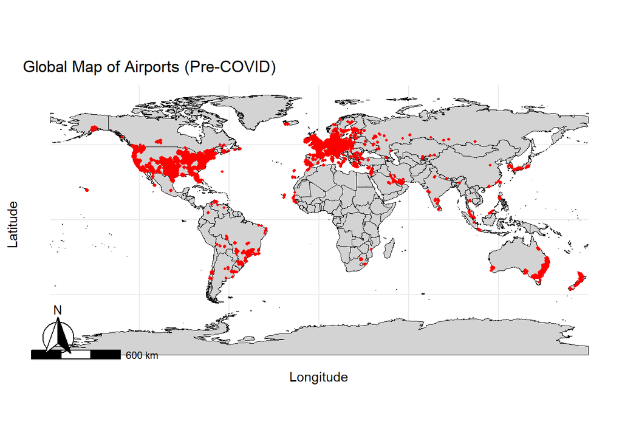

[output not shown]

Based on this point map of airports in the Pre-COVID data set, one can already see that airports are very spatially unevenly distributed from this snapshot, with a large amount of geographical clustering across Europe, the USA, and Eastern Australia. This will not show all airports, only those in use within this snapshot, but it is useful in showing how the network is already spatially unequal.

## Node Strength

```r
cor.test(node_degree2, node_strength2)
cor.test(node_degree3, node_strength3)
```

[output not shown]

During each of the time periods, the flight networks have demonstrated a high Pearson’s correlation between node strength and node degree, of 0.943 and 0.918 for the respective time periods. This is echoed in Hossain et al’s (2013) exploration of Australian flight networks, showing that nodes of high centrality in flight networks also have more traffic. This correlation remains high across all time periods. The drop post-COVID could be explained by some airports maintaining a high degree centrality but experiencing a significant decline in flight frequencies. Moreover, airports may have lost their previously held connections. Thus, the network accessibility had not entirely recovered.

# Network measures

## Pre-COVID

```r
pre_flight_graph <- graph_from_data_frame(aggregated_pre.cov, directed = TRUE)
pre_degree_data <- degree(pre_flight_graph, mode = "all")
```

Network Measures (Pre-COVID)

|  | Node | Betweenness | Degree |
| --- | --- | --- | --- |
| LFPG | LFPG | 18339.380 | 538 |
| EGLL | EGLL | 17955.017 | 709 |
| EHAM | EHAM | 17806.728 | 461 |
| CYYZ | CYYZ | 15333.769 | 230 |
| EDDF | EDDF | 14824.009 | 429 |
| EGSS | EGSS | 11253.525 | 239 |
| EGKK | EGKK | 11124.540 | 331 |
| LEMD | LEMD | 9073.572 | 383 |
| OMDB | OMDB | 8043.118 | 287 |
| LSGG | LSGG | 7732.444 | 246 |

The top 10 airports with the highest betweenness centrality, a measure of the likelihood a node will appear on the shortest path, all occur in Europe with the exception of Toronto and Dubai. All of which also have a high degree centrality, although not in the same sequence. Betweenness centrality can be an indicator of network accessibility, revealing the likelihood a node might facilitate broader network connections. Most of these are in Europe, suggesting that accessibility is higher there, which is home to several major airport hubs. Coupled with the high degree centralities of these nodes, Europe holds a disproportionate level of network accessibility, especially since such nodes are in fact in the minority; most nodes do not possess these characteristics.

## Post-COVID

|  | Node | Betweenness | Degree |
| --- | --- | --- | --- |
| EHAM | EHAM | 26922.799 | 253 |
| OMDB | OMDB | 10561.727 | 210 |
| LFPG | LFPG | 9980.858 | 177 |
| VHHH | VHHH | 9390.394 | 244 |
| CYYZ | CYYZ | 7927.842 | 88 |
| EGLL | EGLL | 7613.303 | 171 |
| EDDK | EDDK | 7302.360 | 102 |
| LEMD | LEMD | 7207.436 | 124 |
| EDDP | EDDP | 6938.791 | 110 |
| OTHH | OTHH | 6382.899 | 166 |

The change in the top 10 compared to the COVID period, is minor, again being dominated by European airports, meaning similar airports consistently preserve their abilities to act as stepping stones within the flight network. However, this still differs slightly from the pre-COVID era which was dominated by European airports, indicating a small improvement in network accessibility.

## Network measures

```r
all_metrics <- Reduce(function(x, y) merge(x, y, by = "Metric", all = TRUE),
                           list(precov_net_metrics, postcov_net_metrics))

colnames(all_metrics) <- c("Metric", "Pre-COVID", "Post-COVID")

kable(all_metrics)
```

| Metric | Pre-COVID | Post-COVID |
| --- | --- | --- |
| Density | 0.0310601 | 0.0147735 |
| Diameter | 11.0000000 | 10.0000000 |
| Mean Distance | 3.1234822 | 3.4783707 |
| Reciprocity | 0.4844933 | 0.4139989 |
| Transitivity | 0.2823918 | 0.2014248 |

The network diameter for the flight network declines between the pre-COVID and COVID periods by 3 units, and only recovers by 2 units post-COVID, not yet meeting pre-pandemic levels. This was initially unexpected, as this report anticipated an increase in diameter during the pandemic due to many routes being temporarily suspended and potentially making some areas much less accessible. However, the opposite seems to be the case, but may be explained by a shrunken network, so there were fewer points to reach. Moreover, there are many instances of nodes only being connected to one or two other nodes.

Network Distance values across the three time periods only increased at each stage by very minor amounts, suggesting that the distance metric is much more resilient than density an diameter metrics appear to be. The distance may stay intact if longer routes within the network remained in place, and because of the ability of the hub-and-spoke model to preserve network accessibility during this period.

# Summary

The flight network, as shown by the distribution of airports pre-COVID, was already very spatially uneven, which already sets the limits to network accessibility. This uneven accessibility is mirrored in the comparative network densities for each time period, which are all very low, suggesting again that the data is very skewed and that only a few of the nodes in the low density network hold most of the connections.

The hypothesis that network accessibility declined during COVID can be reasonable accepted, as many centrality measures, and network parameters, indicate that peripheral nodes were likely excluded from the network, and the domination of European nodes remains consistent. There is also indication of a slow return to normality, given that the statistics were yet to return to pre-COVID levels.

## **6.3. RQ1**

## Log-log degree distributions

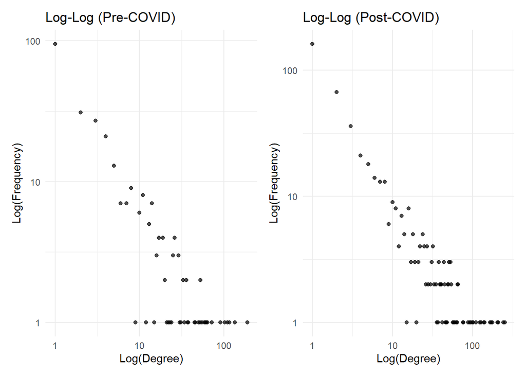

This shows that the hubs within this network are very important to the network functioning, given their significantly larger degree than most other airports. Similar to the correlation results, this importance does not change across time-periods, indicating a resilience to the hub-and-spoke model in times of crisis.

# Network visualisation

## Pre-COVID

To make these network visualisations, the first step was to exclude the lower value nodes, which in my examples is the bottom 75% percentile, otherwise the network visualisation would not be legible. These are based on the edge frequencies.

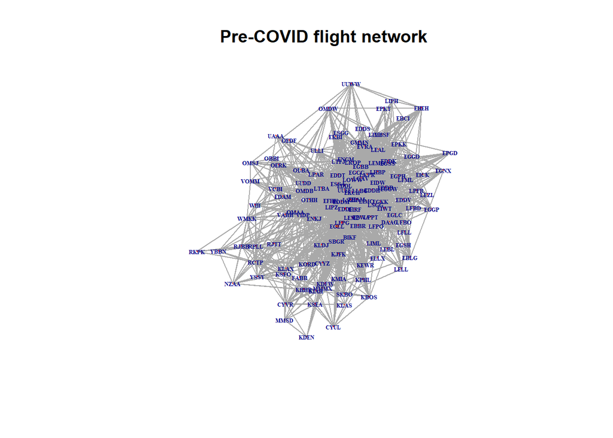

## Post-COVID

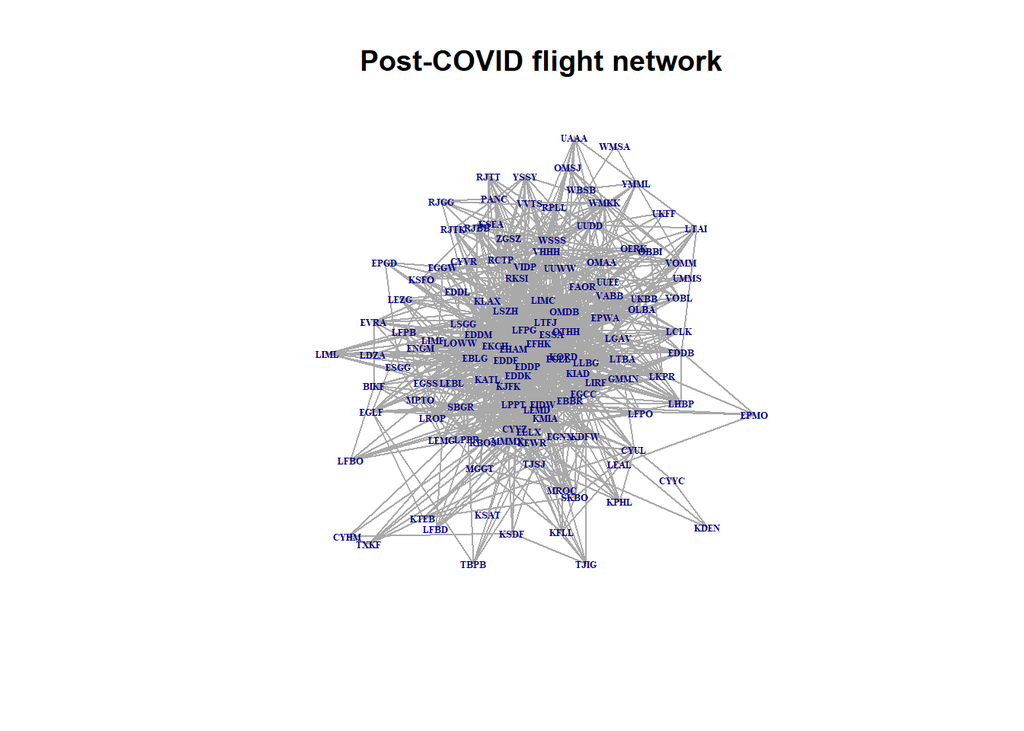

The visualisations of the networks show that there seems to be a lot of clustering within the network around several likely major airport hubs in the centre, showing the importance of central hubs within the hub-and-spoke model, with several periphery airports which may only have a few connections to the network. There appears to be a trend in each time period that the further the node if from the centre, the fewer the edges. For the Post-COVID network visualisation, as opposed to the Pre-COVID graph, there seem to be quite a few nodes on the periphery which only have one or very few connections to the wider network, which is consistent with the fact that many flight paths may not yet have become viable. One limitation of these graphs is that they do not show the direction of the connections, but this is not necessary since the in-degree and out-degree centralities are highly correlated based on the output of a Pearson’s correlation test (0.902 Pre-COVID; 0.938 Post-COVID), as well as the levels of network reciprocity being quite high across all time periods.

# 7. **Limitations**

While this report has attempted a comprehensive review of flight network dynamics during COVID, there remain several limitations.

First, the OpenSky dataset did not extend beyond 2021, which means a truly ‘post-COVID’ variable was not accessible. The referral to post-COVID is limited and only representative of a period when COVID restrictions began to be alleviated.

Moreover, the data only provides snapshots of the flight network, rather than data aggregated to the month level. The months selected in the analysis are also not consistent (January, April, and December respectively), which would show different patterns regardless of the pandemic.

Lastly, passenger numbers were not included as a variable, which may be because not all flights in the data frame were passenger flights. Some previous literature investigating flight dynamics uses such data, but this report uses flight frequencies, which may be more effective to encapsulate both passenger and cargo flights.

# 8. **Conclusion**

In conclusion, the research questions and hypotheses provide valuable insights into the dynamic structure of the flight network in response to crisis.

The hub-and-spoke model appears to have remained resilient, as there appears to be no change in the distribution of airports with a high degree centrality; these nodes also remained a minority across all periods. Clearly, hubs remained important to the functioning of the network. Flight network visualisations reinforce this conclusion, as they have consistently appeared clustered around hubs.

Lastly, airport community structures have changed over the course of the pandemic, becoming much more in-line with regions and continents. This notion is echoed in the literature that points to a shift in protectionism and localisation, which economic policy and urban planning must pay attention to.

For urban and economic planning, this analysis is important in highlighting how international flights and dynamics respond to crisis, pointing to vulnerable areas of the network that must be improved to mitigate against future crisis.

**Word count: 3,486**

# **Reference List**

Agnew, J. (1994) ‘The territorial trap: The geographical assumptions of international relations theory’, *Review of International Political Economy,* 1(1), pp.53-80.

Azzam, M. (2017) ‘The evolution of airports from a network perspective - an analytical concept’, *Chinese Journal of Aeronautics,* 30(2).

Bouwer, J., Krishnan, V. and Saxon, S. (2020) *Will airline hubs recover from COVID-19?.* Available at: https://www.mckinsey.com/industries/travel-logistics-and-infrastructure/our-insights/will-airline-hubs-recover-from-covid-19 (Accessed: 5 November 2024).

Cresswell, T. (2020) ‘Valuing mobility in a post COVID-19 world’, *Mobilities,* 16(1), pp.51-65.

Derr, A. (2023) *What is a Hub-and-Spoke Network: 9 Tips, Benefits & Limitations.* Available at: https://visiblenetworklabs.com/2023/06/05/what-is-a-hub-and-spoke-network/ (Accessed: 27 November 2024).

Gelhausen, M., Berster, P. and Wilken, D. (2021) ‘Post-COVID-19 Scenarios of Global Airline Traffic until 2040 That Reflect Airport Capacity Constraints and Mitigation Strategies’, *Aerospace,* 8(10), pp.1-18.

Hoffman, M. (2021) *Methods for Network Analysis*. Available at: https://bookdown.org/markhoff/social_network_analysis/ (Accessed: 27 November 2024).

Hossain, M., Alam, S., Rees, T., Abbass, H. (2013) ‘Australian Airport Network Robustness Analysis: A Complex Network Approach’, *Australian Transport Research Forum 2013 Proceedings.* Brisbane, 2-4 October. Crawley: Planning and Transport Research Centre.

International Airport Review (2023) *The top 10 busiest airports in the world by cargo handled.* Available at: https://www.internationalairportreview.com/article/107921/top-10-busiest-airports-world-cargo/ (Accessed: 27 November 2024).

Kang, M., Choi, Y., Kim, J., Lee, K., Lee, S., Park, I., Park, J. and Seo, I. (2020) ‘COVID-19 impact on city and region: what’s next after lockdown?’, *International Journal of Urban Studies,* 24(3), pp.297-315.

Karuwa, T. (2024) *Casablanca Airport Still Hasn’t Recovered From COVID-19 Despite 28% Growth.* Available at: https://simpleflying.com/casablanca-airport-not-recovered-despite-growth/ (Accessed: 27 November 2024).

Li, W. and Cai, X. (2004) ‘Statistical analysis of airport network of China’, *Physical Review E,* 69(4).

Mueller, F. (2021) ‘Examining COVID-19-triggered changes in spatial connectivity patterns in the European air transport network up to June 2021’, *Research in Transportation Economics,* 94(1), pp.1-15.

Open Flights (no date) *Airport, airline and route data.* Available at: https://openflights.org/data.php (Accessed: 1 November 2024).

Our World in Data (no date) *World regions according to Our World in Data.* Available at: https://ourworldindata.org/grapher/continents-according-to-our-world-in-data?tab=table (Accessed: 4 November 2024).

Pele, T. (2023) *From grounded to takeoff: In-depth analysis of air traffic recovery after Covid-19 by regions (2020-2023).* Available at: https://spire.com/blog/aviation/air-traffic-recovery-after-covid-19/ (Accessed: 5 November 2024).

Rodrigue, J.P. (2020) *The Geography of Transport Systems.* Available at: https://transportgeography.org/media/ (Accessed: 12 November 2024).

Varghese, J. (2020) *The role of data during Covid-19: Solutions for the airfreight industry.* Available at: https://spire.com/blog/aviation/the-role-of-data-during-covid-19-solutions-for-the-airfreight-industry/ (Accessed: 10 November 2024).

Wang, F., Zou, S. and Liu, Y. (2020) ‘Territorial Traps in Controlling the COVID-19 Pandemic’, *Dialogues in Human Geography,* 10(2), pp.154-157.

Zhang, L., Hou, M., Liu, Y., Wang, K. and Yang, H. (2022) ‘Measuring Beijing’s international air connectivity and suggestions for improvement post COVID-19’, *Transport Policy,* 116, pp.132-143.